# Pima Indians Diabetes Dataset

### Viewing the Data

First, let us import the data and view a summary of the data frame.

```r
diabetes_data <- read.csv('./diabetes.csv', header = TRUE)

# Print simple summary for our data frame
getSummary <- function(data) {
  frameDim <- dim(data)
  print(paste('Features: ', frameDim[2], ' | ', 'Entries: ', frameDim[1]))
  print(str(diabetes_data))
}

getSummary(diabetes_data)
```

```
## [1] "Features:  9  |  Entries:  768"
## 'data.frame':    768 obs. of  9 variables:
##  $ Pregnancies             : int  6 1 8 1 0 5 3 10 2 8 ...
##  $ Glucose                 : int  148 85 183 89 137 116 78 115 197 125 ...
##  $ BloodPressure           : int  72 66 64 66 40 74 50 0 70 96 ...
##  $ SkinThickness           : int  35 29 0 23 35 0 32 0 45 0 ...
##  $ Insulin                 : int  0 0 0 94 168 0 88 0 543 0 ...
##  $ BMI                     : num  33.6 26.6 23.3 28.1 43.1 25.6 31 35.3 30.5 0 ...
##  $ DiabetesPedigreeFunction: num  0.627 0.351 0.672 0.167 2.288 ...
##  $ Age                     : int  50 31 32 21 33 30 26 29 53 54 ...
##  $ Outcome                 : int  1 0 1 0 1 0 1 0 1 1 ...
## NULL
```

#### Imputation

I’ll first check for any bad values in the data set

```r
apply(diabetes_data, 2, function(x) {
  any(is.na(x))
})
```

```
##              Pregnancies                  Glucose            BloodPressure
##                    FALSE                    FALSE                    FALSE
##            SkinThickness                  Insulin                      BMI
##                    FALSE                    FALSE                    FALSE
## DiabetesPedigreeFunction                      Age                  Outcome
##                    FALSE                    FALSE                    FALSE
```

All the columns give false, meaning this data frame does not have any N/A values.

However, it does seem that missing values are represented with a 0. Just for simplicity, I’m going to impute the values using the mean of the column.

```r
bloodPressure_mean <- round(mean(diabetes_data$BloodPressure[diabetes_data$BloodPressure != 0]))
skinThickness_mean <- round(mean(diabetes_data$SkinThickness[diabetes_data$SkinThickness != 0]))
insulin_mean <- round(mean(diabetes_data$Insulin[diabetes_data$Insulin != 0]))

diabetes_data$BloodPressure[diabetes_data$BloodPressure == 0] <- bloodPressure_mean
diabetes_data$SkinThickness[diabetes_data$SkinThickness == 0] <- skinThickness_mean
diabetes_data$Insulin[diabetes_data$Insulin == 0] <- insulin_mean

print(paste('Mean Blood Pressure:', bloodPressure_mean, '| Mean Skin Thickness:',
            skinThickness_mean, '| Mean Insulin:', insulin_mean), collapse = "")
```

```
## [1] "Mean Blood Pressure: 72 | Mean Skin Thickness: 29 | Mean Insulin: 156"
```

#### Correlation Matrix

Next, I want to look at the correlation between the elements.

We first need to convert our data into a correlation matrix.

```r
diab_copy <- diabetes_data
# Convert everything to numeric so we can use the cor() function
diab_copy[, 1:5] <- lapply(diabetes_data[, 1:5], as.numeric)
diab_copy[, 8:9] <- lapply(diabetes_data[, 8:9], as.numeric)

corr_matrix <- diab_copy[, 1:9]
corr_matrix <- round(cor(corr_matrix), 2)
print(corr_matrix)
```

```
##                          Pregnancies Glucose BloodPressure SkinThickness
## Pregnancies                     1.00    0.13          0.21          0.08
## Glucose                         0.13    1.00          0.22          0.18
## BloodPressure                   0.21    0.22          1.00          0.19
## SkinThickness                   0.08    0.18          0.19          1.00
## Insulin                         0.06    0.41          0.07          0.16
## BMI                             0.02    0.22          0.23          0.48
## DiabetesPedigreeFunction       -0.03    0.14          0.00          0.10
## Age                             0.54    0.26          0.32          0.13
## Outcome                         0.22    0.47          0.17          0.21
##                          Insulin  BMI DiabetesPedigreeFunction  Age
## Pregnancies                 0.06 0.02                    -0.03 0.54
## Glucose                     0.41 0.22                     0.14 0.26
## BloodPressure               0.07 0.23                     0.00 0.32
## SkinThickness               0.16 0.48                     0.10 0.13
## Insulin                     1.00 0.15                     0.10 0.14
## BMI                         0.15 1.00                     0.14 0.04
## DiabetesPedigreeFunction    0.10 0.14                     1.00 0.03
## Age                         0.14 0.04                     0.03 1.00
## Outcome                     0.21 0.29                     0.17 0.24
##                          Outcome
## Pregnancies                 0.22
## Glucose                     0.47
## BloodPressure               0.17
## SkinThickness               0.21
## Insulin                     0.21
## BMI                         0.29
## DiabetesPedigreeFunction    0.17
## Age                         0.24
## Outcome                     1.00
```

Now that we have a correlation matrix, I’ll use the corrplot library to graph it, mainly as it seems relatively simple to use and conveys the information I want.

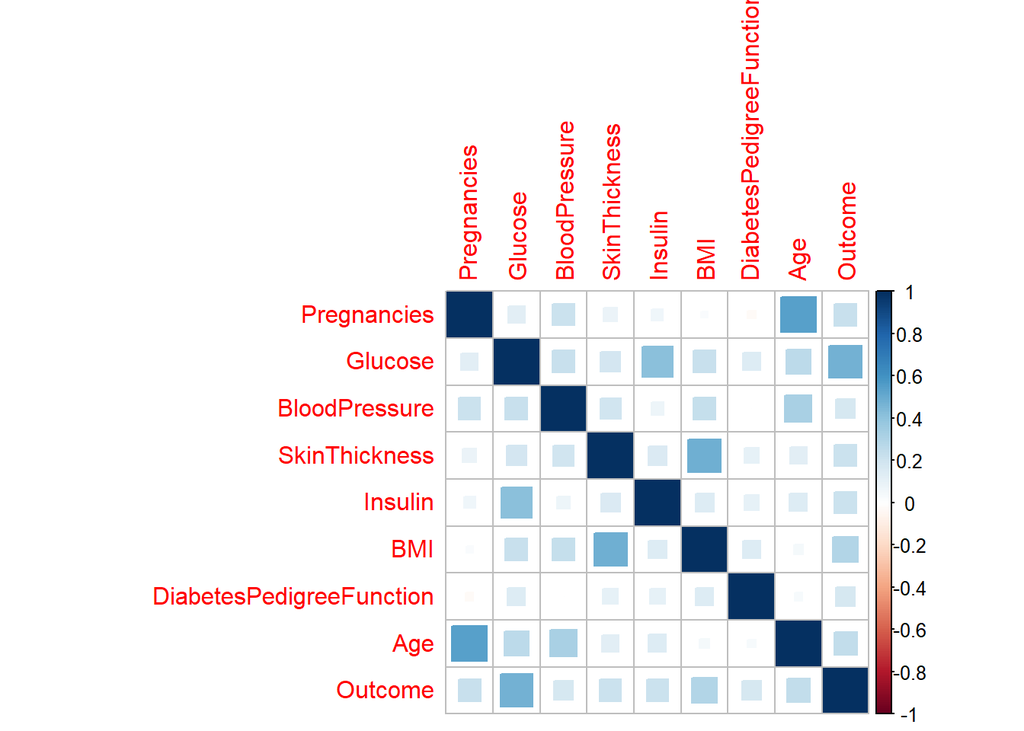

```r
# Convert to matrix as it is required by the corrplot library (it is currently a data frame)
corrplot(as.matrix(corr_matrix), method = "square")
```

Not quite what I wanted. Some of the feature names are too long for the graph to look nice. As a result, I’m going to shorten the column names just for this correlation matrix.

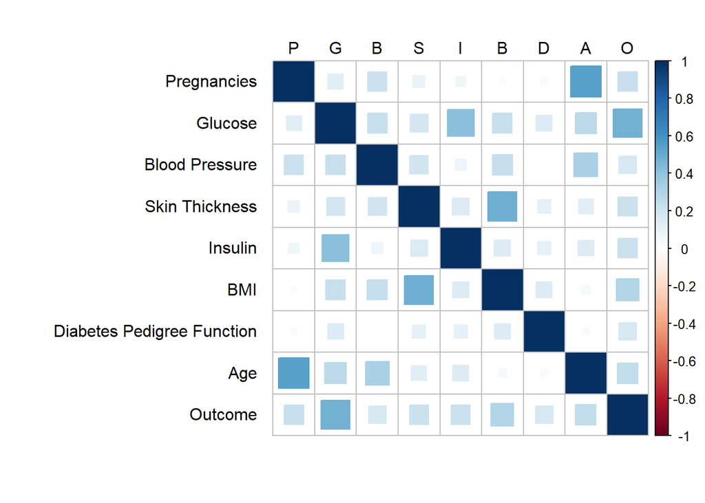

```r
for(i in  1:length(colnames(corr_matrix))) {
  colnames(corr_matrix)[i] <- substr(colnames(corr_matrix)[i], 1, 1)
}

rownames(corr_matrix)[3] <- 'Blood Pressure'
rownames(corr_matrix)[4] <- 'Skin Thickness'
rownames(corr_matrix)[7] <- 'Diabetes Pedigree Function'

corrplot(as.matrix(corr_matrix),
         method = "square",# Display correlation as squares of varying sizes
         tl.col = 'black', # Color of labels
         tl.srt = 0,       # Resets angle of column names to 0
         tl.offset = 0.8)  # Vertically moves up column labels
```

That’s better.

Just looking at the correlation plot, it seems that glucose is strongly correlated with diabetes, and will have a relatively strong effect in our classification tree. Not too surprising.

### Using Random Forests

We should first subset the data into a training and testing set, usually a split of 70% to 30%. Just to remove the small chance the order of the rows might be a factor, I’ll sample the data first.

```r
set.seed(153)

# Gives random vector of row numbers to select
nRows <- dim(diabetes_data)[1]
sampleIndexes <- sample(1:nRows, 0.7*nRows, replace = FALSE)
diabetes_data$Outcome <- as.factor(diabetes_data$Outcome)

train <- diabetes_data[sampleIndexes, ]
test <- diabetes_data[-sampleIndexes, ]

dim(test)
```

```
## [1] 231   9
```

```r
dim(train)
```

```
## [1] 537   9
```

Next, let’s run the random forest algorithm with the default arguments, and factoring in all features.

```r
form <- formula('Outcome ~ .')
rfModel <- randomForest(form, data = train)
prediction <- predict(rfModel, test[, 1:8])
```

We now know our prediction, but we can also try using a slightly different random forest algorithm in the party package for comparison. The ctree function is the party package also allows up to plot a sample tree, giving us a general idea of what the tree looks like.

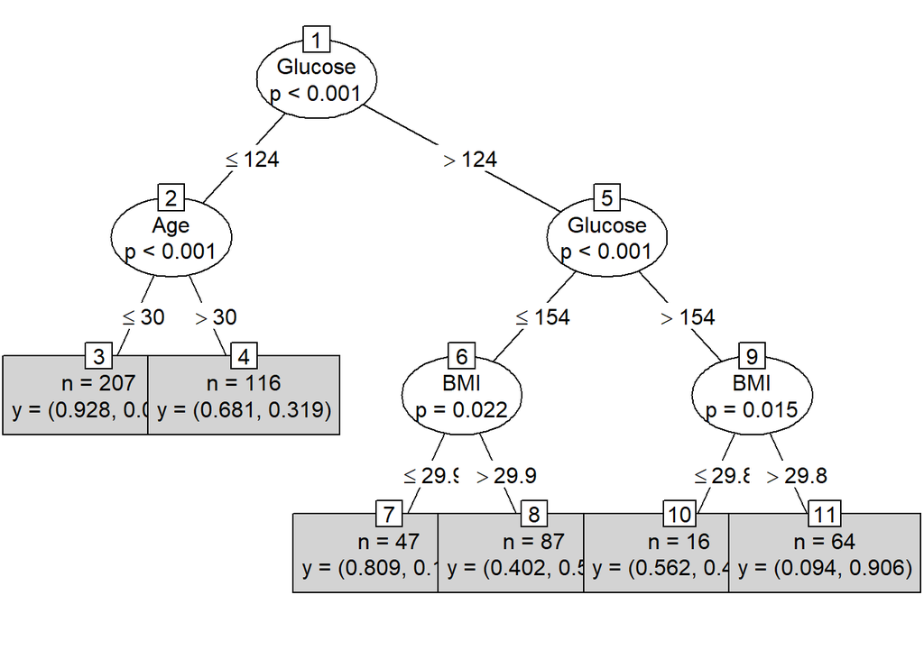

```r
partyRFModel <- ctree(form, data = train)
altPrediction <- predict(partyRFModel, test[, 1:8])
plot(partyRFModel, type = "simple")
```

Now, I want to add the predictions to the test data frame and compare the rows to see the accuracy of the model.

```r
test$Prediction1 <- prediction
test$Prediction2 <- altPrediction

testEql <- test[test$Outcome == test$Prediction1, ]
altTestEql <- test[test$Outcome == test$Prediction2, ]

rfAcc = dim(testEql)[1] / dim(test)[1]
altRfAcc = dim(altTestEql)[1] / dim(test)[1]
print(paste(c('Accuracy of RF Tree:', round(rfAcc, 3) * 100, '%'), collapse = " "))
```

```
## [1] "Accuracy of RF Tree: 72.7 %"
```

```r
print(paste(c('Accuracy of Party RF Tree:', round(altRfAcc, 3) * 100, '%'), collapse = " "))
```

```
## [1] "Accuracy of Party RF Tree: 69.7 %"
```

Seems we get about a 70-74% accuracy. Not the worst in the world.

Because I don’t want to repeat code, I’m going to abstract the above code into a function.

```r
actualOutcome <- test$Outcome

getAccuracyofRFModel <- function(formula, train, test, nTree = 500, mTry = sqrt(8)) {
  rfModel <- randomForest(form, data = train, ntree = nTree, mtry =)
  prediction <- predict(rfModel, test[, 1:8])
  testEql <- test[test$Outcome == prediction, ]
  rfAcc = dim(testEql)[1] / dim(test)[1]
  return(round(rfAcc, 3))
}
```

Now that we have a function, we can try different values of nTree and mTry to see what we get.

```r
nTreeVals <- c(5, 50, 100, 300, 500, 700, 1000)
mTryVals <- c(1, 2, 3, 4, 5)
for(ntree in nTreeVals) {
  percent <- getAccuracyofRFModel(form, train, test, ntree, sqrt(8))
  text <- paste(c(ntree, ': ', percent), collapse = ' ')
  print(text)
}
```

```
## [1] "5 :  0.706"
## [1] "50 :  0.727"
## [1] "100 :  0.727"
## [1] "300 :  0.727"
## [1] "500 :  0.749"
## [1] "700 :  0.74"
## [1] "1000 :  0.736"
```

```r
for(mtry in mTryVals) {
  percent <- getAccuracyofRFModel(form, train, test, 500, mtry)
  text <- paste(c(mtry, ': ', percent), collapse = ' ')
  print(text)
}
```

```
## [1] "1 :  0.74"
## [1] "2 :  0.74"
## [1] "3 :  0.74"
## [1] "4 :  0.74"
## [1] "5 :  0.74"
```